## Sea Surface Temperature Pressure Layer for OHI 2015

If the data produced here is used in publication, please make attribution clear. For citation see the most current release here

### Data

Data comes from [CoRTAD version 5](https://data.noaa.gov/dataset/the-coral-reef-temperature-anomaly-database-cortad-version-5-global-4-km-sea-surface-temperatub705f)

**Native Data Resolution**: 4km  
**Values**: Temperature in Kelvin  
**Time Range**: 1982 - 2012 (weekly averages across all years)  
**Format**: NetCDF

### Methods Overview

For full procedure see create_sst_layer.html:

For each week (1 to 53) across all years, the standard deviation of Weekly SST averages is calculated. As an example here is the standard deviation for week 1 across all years:

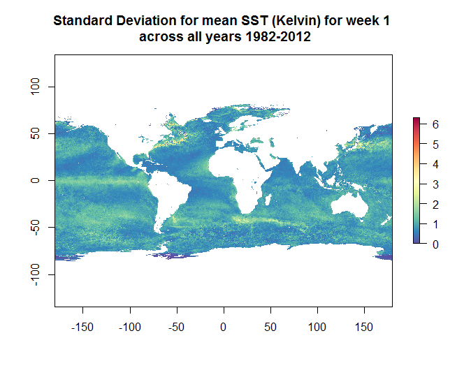

Then, for every year we are interested in knowing how many weeks are anomalous (defined as greater than the standard deviation). Negative anomalies are ignored.

Each week in a year is compared against the standard deviation for that week, and if the cell is greater, it is assigned a 1. This creates a single raster layer for each year from 1982 to 2012 that shows the number of anomalous weeks each cell has (from 0 to 53). Here is an example for 2012:

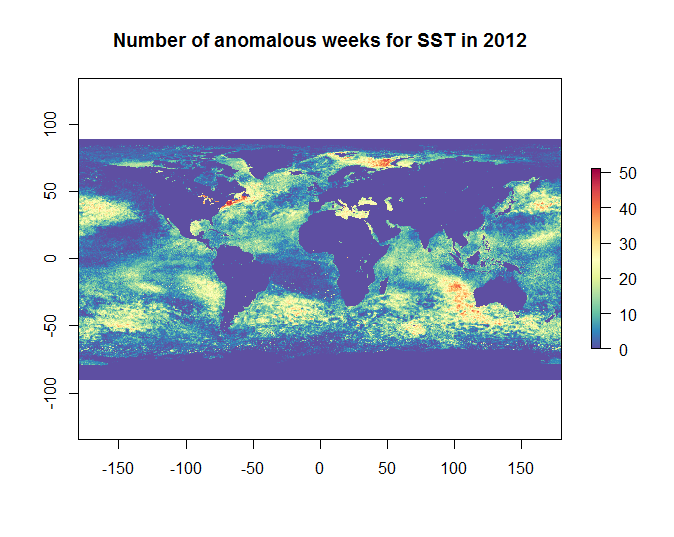

The SST pressure layer is created by looking at the change in these anomalies between the 5 most recent year (2008-2012)s, and 5 historical years (1985-1989). The years 1985-1989 were chosen to avoid the large El Nino event in 1982-1983.

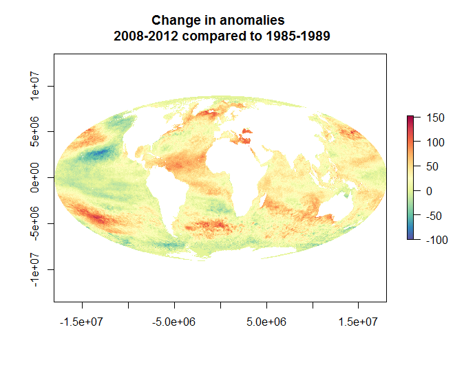

This layer was rescaled from 0 to 1 using the 99.99th quantile as a reference point.

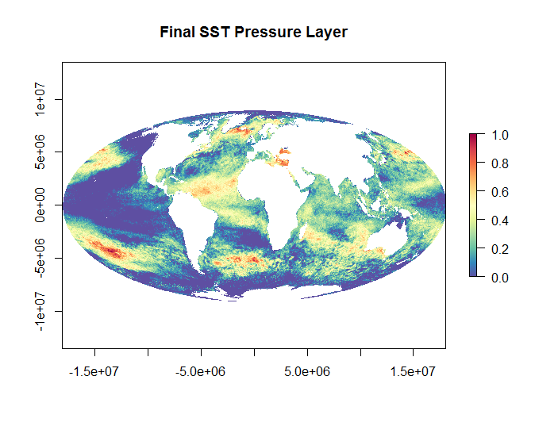

**References**

CoRTAD v5